# Twitter feed experiment pilot study V2

# Sample Summary

```r
# i want to know how many tweets each respondent has seen
agg_df <- df %>%
    group_by(workerID, fox_user, treatment_group, event, is_fox) %>%
    count() %>%
    filter(!is.na(treatment_group))
n_installs <- df %>%
    filter(event == "install") %>%
    select(workerID) %>%
    distinct() %>%
    count()
n_users_active <- df %>%
    filter(event == "show") %>%
    select(workerID) %>%
    distinct() %>%
    count()
rate <- n_users_active / n_installs
```

130 unique users installed the extension (completed presurvey).

74 have used twitter since installation.

The average active user per install rate is 0.5692308.

## Study progress

Installs by treatment group

```r
agg_df %>%
    group_by(treatment_group) %>%
    summarize(
        installs = sum(as.numeric(event == "install") * n),
        twitter_users = n_distinct(workerID[event == "show"]),
        fox_users = n_distinct(workerID[is_fox]),
    )
```

```
## # A tibble: 3 x 4
##   treatment_group installs twitter_users fox_users
##             <dbl>    <dbl>         <int>     <int>
## 1               0       42            24        10
## 2               1       38            22         8
## 3               2       50            28         8
```

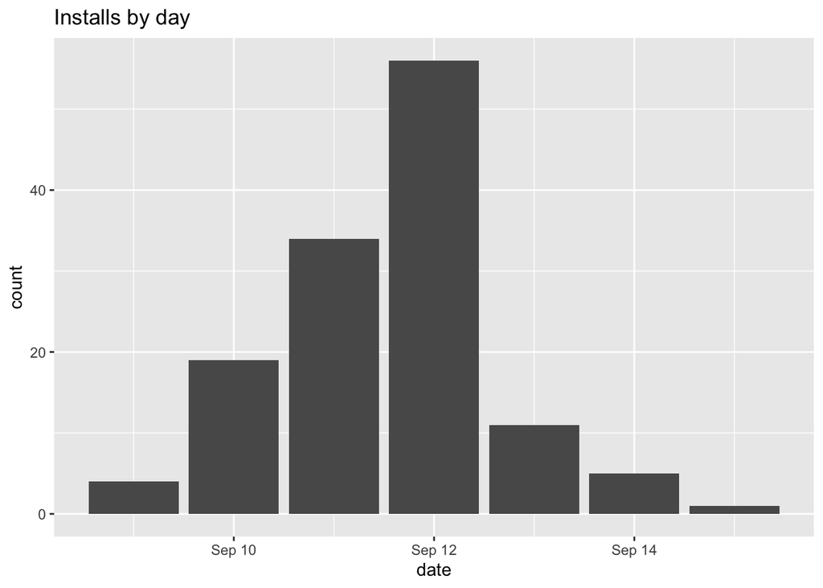

```r
df %>%
    filter(event == "install") %>%
    group_by(date) %>%
    summarize(count = n()) %>%
    ggplot(aes(x = date, y = count)) +
    geom_bar(stat = "identity") +
    labs(title = "Installs by day")
```

```r
# Write the IDs of each install per day so we can launch the appropriate pre-survey
df %>%
    filter(event == "install") %>%
    group_by(date) %>%
    summarize(ids = paste0(workerID, collapse = ","), n = n()) %>%
    select(date, n, ids) %>%
    write.csv("ids_per_day.tsv", sep = "\t")
```

How many people uninstalled the twitter app?

```r
survey_df$uninstall %>% table()
```

```
## .
## FALSE  TRUE
##    12    84
```

```r
survey_df %>%
    filter(uninstall == 1) %>%
    mutate(bonus = "2.00") %>%
    select(PROLIFIC_PID, bonus) %>%
    write.csv(file = "bonuses.csv", row.names = FALSE, col.names = NA, quote = FALSE)
```

## Endline Survey

```r
survey_df$postsurvey %>% table()
```

```
## .
## FALSE  TRUE
##    16   118
```

```r
summary(as.factor(survey_df$pid3))
```

```
##    Democrat Independent  Republican        NA's
##          67          39          26           2
```

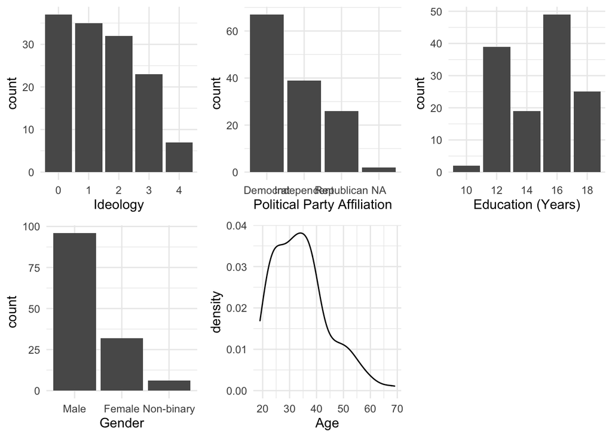

```r
ggarrange(
    survey_df %>%
        ggplot(aes(x = as.factor(ideo))) +
        geom_bar() +
        theme_minimal() +
        labs(x = "Ideology"),
    survey_df %>%
        ggplot(aes(x = pid3)) +
        geom_histogram(stat = "count") +
        theme_minimal() +
        labs(x = "Political Party Affiliation"),
    survey_df %>%
        ggplot(aes(x = as.factor(educ))) +
        geom_bar() +
        theme_minimal() +
        labs(x = "Education (Years)"),
    survey_df %>%
        ggplot(aes(x = gender)) +
        geom_histogram(stat = "count") +
        theme_minimal() +
        labs(x = "Gender"),
    survey_df %>%
        ggplot(aes(x = age)) +
        geom_density() +
        theme_minimal() +
        labs(x = "Age")
)
```

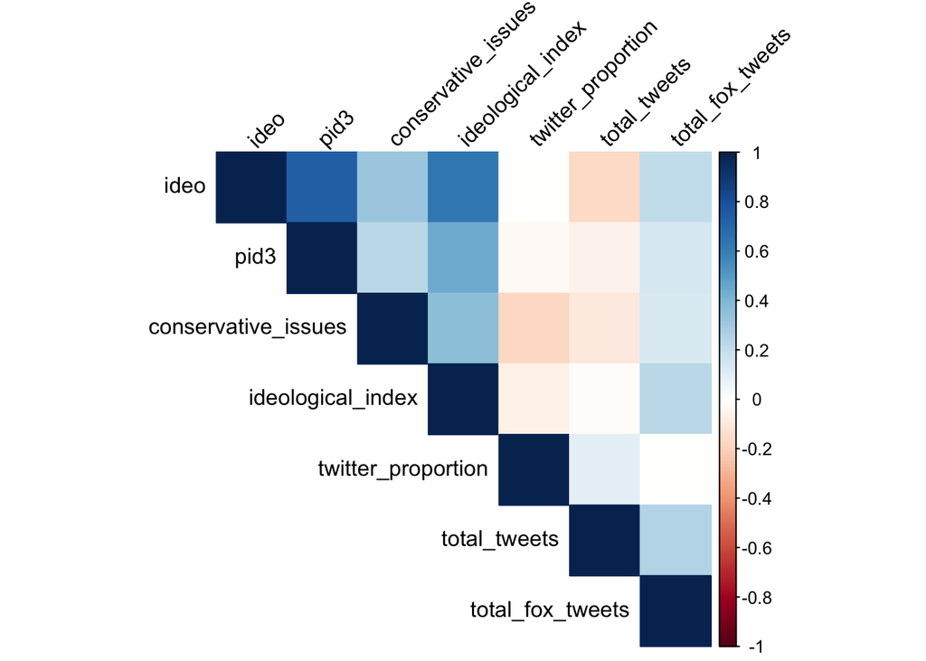

```r
ggsave("figures/sample_characteristics.png", width = 8, height = 6)

library(corrplot)
model <- cor(survey_df %>% mutate(
    conservative_issues = conservative_priorities_index,
    internet_usage = twitter_proportion,
    pid3 = factor(pid3, levels = c("Democrat", "Independent", "Republican")) %>% as.numeric(),
) %>% select(
    "ideo", "pid3", "conservative_issues", "ideological_index", "twitter_proportion", "total_tweets", "total_fox_tweets",
), use = "complete.obs")
corrplot(model,
    method = "color",
    type = "upper",
    tl.srt = 45,
    tl.col = "black"
)
```

## Twitter usage

Tweets seen by group

```r
agg_df %>%
    group_by(treatment_group) %>%
    summarize(
        tweets_shown = sum(as.numeric(event == "show") * n),
        fox_users_tweets_shown = sum(as.numeric(fox_user) * n),
        fox_users_tweets_hidden = sum(as.numeric(is_fox) * n, na.rm = TRUE)
    )
```

```
## # A tibble: 3 x 4
##   treatment_group tweets_shown fox_users_tweets_shown fox_users_tweets_hidden
##             <dbl>        <dbl>                  <dbl>                   <dbl>
## 1               0        12336                  10191                      48
## 2               1        19811                  10444                      36
## 3               2        23352                   9701                      22
```

Distribution of twitter activity

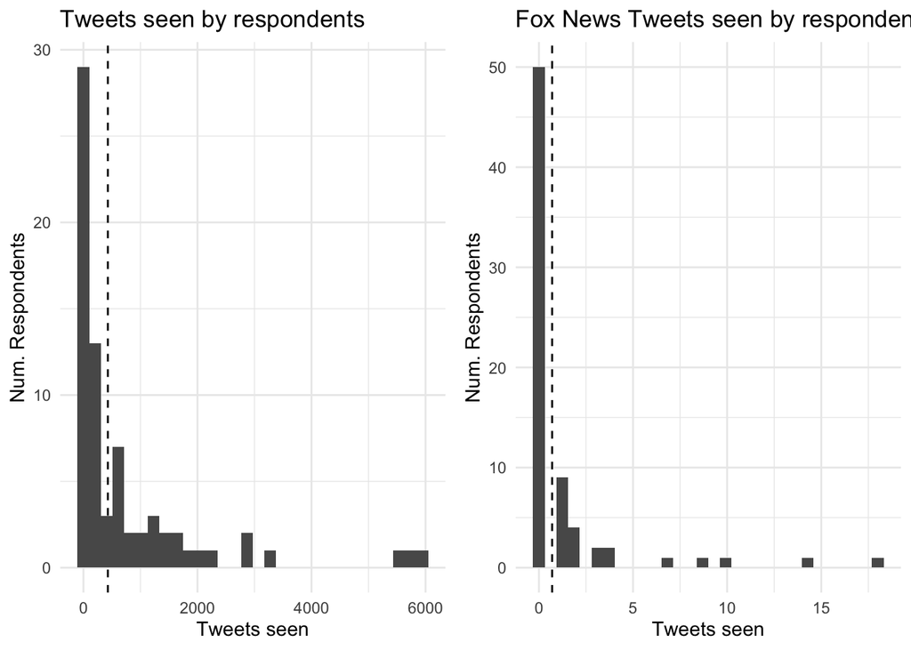

```r
tweets_seen_plot <- survey_df %>%
    filter(total_tweets > 0) %>%
    ggplot(aes(x = total_tweets)) +
    geom_vline(xintercept = mean(survey_df$total_tweets, na.rm = TRUE), linetype = "dashed") +
    geom_histogram() +
    theme_minimal() +
    labs(title = "Tweets seen by respondents", x = "Tweets seen", y = "Num. Respondents")
fox_tweets_seen_plot <- survey_df %>%
    filter(total_tweets > 0) %>%
    ggplot(aes(x = total_fox_tweets)) +
    geom_vline(xintercept = mean(survey_df$total_fox_tweets, na.rm = TRUE), linetype = "dashed") +
    geom_histogram() +
    theme_minimal() +
    labs(title = "Fox News Tweets seen by respondents", x = "Tweets seen", y = "Num. Respondents")

ggarrange(tweets_seen_plot, fox_tweets_seen_plot)
```

```r
ggsave(paste0("figures/tweets.png"), width = 10, height = 5)
```

## Checking instruments for twitter usage

Did agreeing to uninstall the Twitter app actually impact observed twitter usage?

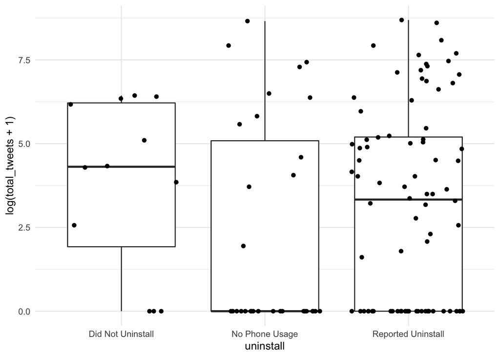

```r
survey_df %>%
    mutate(
        uninstall = case_when(
            uninstall == TRUE ~ "Reported Uninstall",
            uninstall == FALSE ~ "Did Not Uninstall",
            is.na(uninstall) ~ "No Phone Usage"
        ),
    ) %>%
    ggplot(aes(x = uninstall, y = log(total_tweets + 1))) +
    geom_boxplot() +
    geom_point(position = "jitter") +
    theme_minimal()
```

conclusion: we don’t really know, but not really

Are people that report not using the internet much not using Twitter much?

[figure not shown]

```r
survey_df %>% ggplot(aes(x = as.factor(media_internet), y = log(total_tweets))) +
    geom_boxplot() +
    geom_point(position = "jitter") +
    theme_minimal() +
    labs(
        x = "Reported Internet Usage Frequency Per Week",
        y = "Tweets Seen (log)",
        title = "Twitter Activity by Reported Internet Usage"
    )
```

[figure not shown]

```r
survey_df %>%
    filter(total_tweets > 0) %>%
    ggplot(aes(x = twitter_proportion, y = log(total_tweets))) +
    geom_point() +
    geom_smooth(method = "lm") +
    theme_minimal() +
    labs(
        x = "Reported Internet Usage Proportion (to Other Media)",
        y = "Tweets Seen (log)",
        title = "Twitter Activity by Reported Internet Usage"
    )
```

## Balance check

### Love Plots

```r
fmla <- treated ~ ideo + age + gender + educ + total_tweets + total_fox_tweets
t1 <- love.plot(fmla,
    data = survey_df %>% filter(treatment_group %in% c(0, 1)),
    stats = c("mean.diffs"),
    thresholds = c(m = 0.1, v = 2),
    abs = FALSE,
    binary = "std",
    var.order = "unadjusted",
    drop.distance = TRUE
) + theme(legend.position = "none") + labs(title = "")
```

```
## Note: 's.d.denom' not specified; assuming pooled.
```

```r
t2 <- love.plot(fmla,
    data = survey_df %>% filter(treatment_group %in% c(0, 2)),
    stats = c("mean.diffs"),
    thresholds = c(m = 0.1, v = 2),
    abs = FALSE,
    binary = "std",
    var.order = "unadjusted",
    drop.distance = TRUE
) + theme(legend.position = "none") + labs(title = "")
```

```
## Note: 's.d.denom' not specified; assuming pooled.
```

```r
t3 <- love.plot(social ~ ideo + age + gender + educ + total_tweets + total_fox_tweets,
    data = survey_df %>% filter(treatment_group %in% c(1, 2)),
    stats = c("mean.diffs"),
    thresholds = c(m = 0.1, v = 2),
    abs = FALSE,
    binary = "std",
    var.order = "unadjusted",
    drop.distance = TRUE
) + theme(legend.position = "none") + labs(title = "")
```

```
## Note: 's.d.denom' not specified; assuming pooled.
```

```r
ggarrange(
    t1, t2, t3,
    labels = c("Links vs Control", "Accounts vs Control", "Links vs Accounts")
)
```

[figure not shown]

### Covariate balance table

```r
means <- survey_df %>%
    group_by(treatment_group) %>%
    summarize(
        mean_ideo = mean(ideo),
        mean_educ = mean(educ),
        mean_age = mean(age),
        mean_gender = mean(as.numeric(gender) - 1),
        mean_total_tweets = mean(total_tweets),
        num_saw_tweets = sum(total_tweets > 0),
        num_saw_fox = sum(total_fox_tweets > 0),
        mean_total_fox_tweets = mean(total_fox_tweets),
        ideo_sd = sd(ideo),
        educ_sd = sd(educ),
        age_sd = sd(age),
        gender_sd = sd(as.numeric(gender) - 1),
        tt_sd = sd(total_tweets),
        fox_tt_sd = sd(total_fox_tweets),
        n = n(),
        ideo_se = ideo_sd / sqrt(n),
        educ_se = educ_sd / sqrt(n),
        age_se = age_sd / sqrt(n),
        gender_se = gender_sd / sqrt(n),
        tt_se = tt_sd / sqrt(n),
        fox_tt_se = fox_tt_sd / sqrt(n),
    ) %>%
    mutate_all(round, 2) %>%
    mutate(
        Treatment = recode(treatment_group, "1" = "Accounts", "2" = "Link", "0" = "Control"),
        Ideology = paste0(mean_ideo, " (", ideo_se, ")"),
        Education = paste0(mean_educ, " (", educ_se, ")"),
        Age = paste0(mean_age, " (", age_se, ")"),
        Female = paste0(mean_gender, " (", gender_se, ")"),
        Tweets_Seen = paste0(mean_total_tweets, " (", tt_se, ")"),
        Fox_Tweets_Seen = paste0(mean_total_fox_tweets, " (", fox_tt_se, ")"),
        Twitter_Users = round(num_saw_tweets, 0),
        Saw_Fox = round(num_saw_fox, 0),
        Count = round(n, digits = 0)
    )
library(xtable)
print(xtable(means %>% select(Treatment, Count, Ideology, Education, Age, Female), type = "latex"), file = "covariate_means.tex")
print(xtable(means %>% select(Treatment, Twitter_Users, Saw_Fox, Tweets_Seen, Fox_Tweets_Seen), type = "latex"), file = "covariate_means_2.tex")
```

```r
models <- list(
    lm(treated ~ ideo + educ + age + gender + total_tweets + total_fox_tweets, data = survey_df %>% filter(treatment_group %in% c(0, 1))),
    lm(treated ~ ideo + educ + age + gender + total_tweets + total_fox_tweets, data = survey_df %>% filter(treatment_group %in% c(0, 2))),
    lm(social ~ ideo + educ + age + gender + total_tweets + total_fox_tweets, data = survey_df %>% filter(treatment_group %in% c(1, 2)))
)
stargazer(
    models,
    type = "html",
    out = "covariate_balance.tex"
)
```

|  | *Dependent variable:* |  |  |
| --- | --- | --- | --- |
|  | treated |  | social |
|  | (1) | (2) | (3) |
| ideo | -0.022 | -0.002 | 0.013 |
|  | (0.049) | (0.045) | (0.051) |
| educ | -0.009 | -0.010 | -0.013 |
|  | (0.027) | (0.024) | (0.026) |
| age | 0.001 | -0.004 | -0.006 |
|  | (0.006) | (0.005) | (0.006) |
| genderFemale | -0.253* | -0.332*** | -0.118 |
|  | (0.128) | (0.119) | (0.155) |
| genderNon-binary | 0.408 | 0.308 | -0.003 |
|  | (0.371) | (0.299) | (0.245) |
| total_tweets | 0.0001 | 0.00003 | -0.00001 |
|  | (0.0001) | (0.0001) | (0.0001) |
| total_fox_tweets | -0.026 | -0.025 | -0.008 |
|  | (0.022) | (0.021) | (0.038) |
| Constant | 0.691* | 0.931** | 0.976** |
|  | (0.401) | (0.402) | (0.406) |
| Observations | 78 | 90 | 86 |
| R<sup>2</sup> | 0.113 | 0.149 | 0.029 |
| Adjusted R<sup>2</sup> | 0.024 | 0.077 | -0.058 |
| Residual Std. Error | 0.496 (df = 70) | 0.481 (df = 82) | 0.512 (df = 78) |
| F Statistic | 1.276 (df = 7; 70) | 2.057* (df = 7; 82) | 0.330 (df = 7; 78) |
| *Note:* | p<0.1; p<0.05; p<0.01 |  |  |

## What content did users see?

```r
# content plots
df <- df %>% mutate(
    media = case_when(
        blacklist_author ~ "Fox",
        str_detect(author, "MSNBC") ~ "MSNBC",
        str_detect(author, "CNN") ~ "CNN",
        str_detect(author, "[bB]reitbart") ~ "Breitbart",
        str_detect(author, "thegatewaypundit") ~ "Gateway Pundit",
        str_detect(author, "nytimes") ~ "New York Times",
        str_detect(author, "(?i)newyorker") ~ "New Yorker",
        str_detect(author, "Slate") ~ "Slate",
        str_detect(author, "(?i)thedailyshow") ~ "TheDailyShow",
        str_detect(author, "(?i)guardian") ~ "The Guardian",
        str_detect(author, "(?i)maddow") ~ "Rachel Maddow",
        str_detect(author, "(?i)buzzfeed") ~ "Buzzfeed",
        str_detect(author, "(?i)pbs") ~ "PBS",
        str_detect(author, "(?i)bbc") ~ "BBC",
        str_detect(author, "(?i)TheEconomist|EconUS") ~ "The Economist",
        str_detect(author, "(?i)politico") ~ "Politico",
        str_detect(author, "washingtonpost") ~ "Washington Post",
        str_detect(author, "usatoday") ~ "USA Today",
        str_detect(author, "latimes") ~ "LA Times",
        str_detect(author, "espn") ~ "ESPN",
        str_detect(author, "nbc") ~ "NBC",
        str_detect(author, "cbs") ~ "CBS",
        str_detect(author, "forbes") ~ "Forbes",
        str_detect(author, "wsj") ~ "Wall St Journal",
        str_detect(author, "huffpost") ~ "Huffington Post"
    ),
    media_links = case_when(
        blacklist_text ~ "Fox",
        str_detect(text, "(?i)MSNBC") ~ "MSNBC",
        str_detect(text, "(?i)CNN") ~ "CNN",
        str_detect(text, "[bB]reitbart") ~ "Breitbart",
        str_detect(text, "(?i)thegatewaypundit") ~ "Gateway Pundit",
        str_detect(text, "(?i)nytimes") ~ "New York Times",
        str_detect(text, "(?i)newyorker") ~ "New Yorker",
        str_detect(text, "(?i)Slate") ~ "Slate",
        str_detect(text, "(?i)thedailyshow") ~ "TheDailyShow",
        str_detect(text, "(?i)guardian") ~ "The Guardian",
        str_detect(text, "(?i)maddow") ~ "Rachel Maddow",
        str_detect(text, "(?i)buzzfeed") ~ "Buzzfeed",
        str_detect(text, "(?i)pbs") ~ "PBS",
        str_detect(text, "(?i)bbc") ~ "BBC",
        str_detect(text, "(?i)TheEconomist|EconUS") ~ "The Economist",
        str_detect(text, "(?i)politico") ~ "Politico",
        str_detect(text, "(?i)washingtonpost") ~ "Washington Post",
        str_detect(text, "(?i)usatoday") ~ "USA Today",
        str_detect(text, "(?i)latimes") ~ "LA Times",
        str_detect(text, "(?i)espn") ~ "ESPN",
        str_detect(text, "(?i)nbc") ~ "NBC",
        str_detect(text, "(?i)cbs") ~ "CBS",
        str_detect(text, "(?i)forbes") ~ "Forbes",
        str_detect(text, "(?i)wsj") ~ "Wall St Journal",
        str_detect(text, "(?i)huffpost") ~ "Huffington Post"
    ),
    keyword = case_when(
        str_detect(text, "(?i)inflation|economy") ~ "Inflation/Economy",
        str_detect(text, "(?i)free speech|censor|cancel") ~ "Free Speech",
        str_detect(text, "(?i)china") ~ "China",
        str_detect(text, "(?i)opioid|fentanyl|heroin") ~ "Opioid Crisis",
        str_detect(text, "(?i)health care|healthcare|obamacare|affordable care act| ACA |health insurance") ~ "Health Care",
        str_detect(text, "(?i)crime rate|public safety|police") ~ "Crime",
        str_detect(text, "(?i)gun") ~ "Gun Control",
        str_detect(text, "(?i)covid|corona|vaccine|mask|pandemic") ~ "Covid-19",
        str_detect(text, "(?i)ukraine|russia|putin") ~ "Russia",
        str_detect(text, "(?i)immigration|border|detain|sanctuary|migrant") ~ "Immigration",
        str_detect(text, "(?i)climate|carbon|emission|environment|greenhouse|solar|paris") ~ "Climate",
        str_detect(text, "[bB]iden") ~ "Biden",
        str_detect(text, "[tT]rump") ~ "Trump",
        str_detect(text, "(?i)dems|democrat|liberal|lib|conservative|gop|republican|obama|clinton") ~ "Other Political Topic",
    ),
    is_media = !is.na(media),
    is_keyword = !is.na(keyword) | political,
    is_media_link = !is.na(media_links)
)
sum(df$is_media)
```

```
## [1] 446
```

```r
sum(df$is_keyword, na.rm = TRUE)
```

```
## [1] 9885
```

```r
sum(df$is_media_link)
```

```
## [1] 1987
```

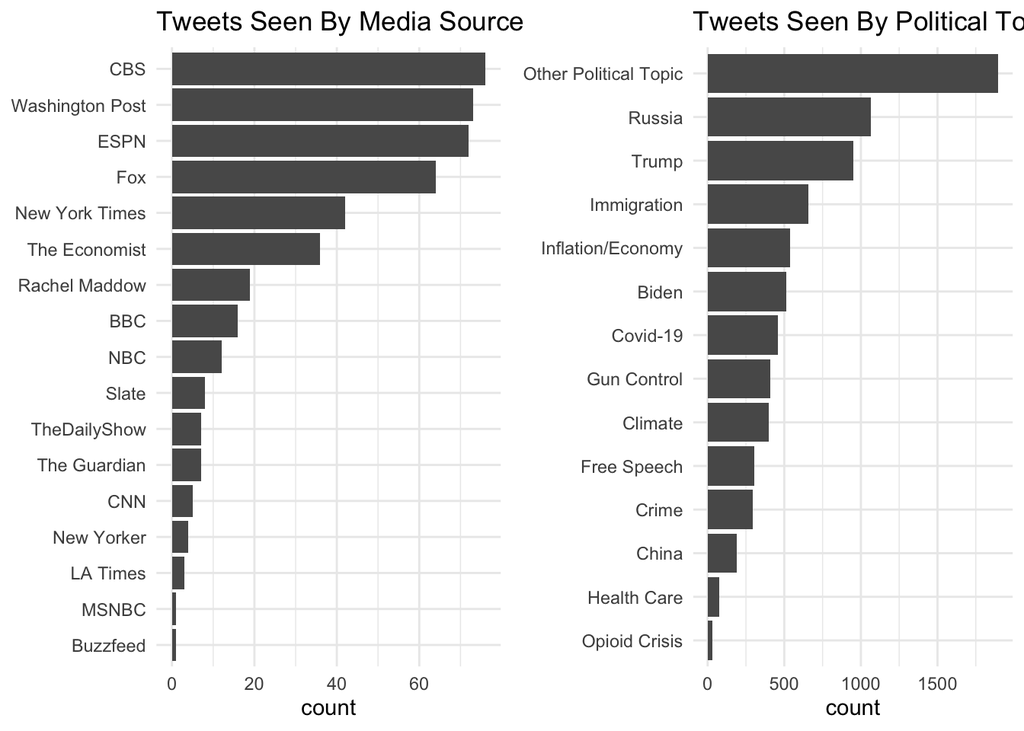

```r
news_plot <- df %>%
    filter(is_media) %>%
    ggplot(aes(x = reorder(media, media, function(x) length(x)))) +
    geom_bar() +
    theme_minimal() +
    theme(axis.title.y = element_blank()) +
    coord_flip() +
    labs(title = "Tweets Seen By Media Source", x = "Count")

topic_plot <- df %>%
    filter(!is.na(keyword)) %>%
    ggplot(aes(x = reorder(keyword, keyword, function(x) length(x)))) +
    geom_bar() +
    theme_minimal() +
    theme(axis.title.y = element_blank()) +
    coord_flip() +
    labs(title = "Tweets Seen By Political Topic", x = "Count")

ggarrange(news_plot, topic_plot)
```

```r
ggsave(paste0("figures/tweet_break.png"), width = 10, height = 5)
```

## What content was hidden?

```r
df %>%
    filter(is_fox) %>%
    mutate(fox_type = case_when(
        blacklist_author ~ "Official Fox Account",
        blacklist_text ~ "Link to Fox Content"
    )) %>%
    group_by(fox_type) %>%
    summarize(n = n())
```

```
## # A tibble: 2 x 2
##   fox_type                 n
##   <chr>                <int>
## 1 Link to Fox Content     42
## 2 Official Fox Account    64
```

```r
# Text processing
library(tm)
df %>%
    filter(is_fox) %>%
    select(author, text) %>%
    write.csv(file = "fox_tweets.csv")
text <- VCorpus(VectorSource(df %>% filter(is_fox) %>% .$text))
text <- tm_map(text, content_transformer(tolower))
toSpace <- content_transformer(function(x, pattern) gsub(pattern, " ", x))
text <- tm_map(text, toSpace, "(f|ht)tp(s?)://(.*)[.][a-z]+")
text <- tm_map(text, toSpace, "[^[:alnum:]]")
text <- tm_map(text, removePunctuation)
text <- tm_map(text, removeNumbers)
text <- tm_map(text, stripWhitespace)
text <- tm_map(text, removeWords, c(
    stopwords("english"),
    "tweet", "retweeted", "foxnews", "fox", "com", "liked", "foxnow",
    "official", "confirmed", "sent", "sends", "get", "will", "show", "two",
    "jackposobiec", "like", "tomilahren", "foxbusiness", "n n", "follow"
))
text <- tm_map(text, removeWords, ~ length(x) > 20)
```

[output not shown]

[output cut: 156 more lines]

[output not shown]

```r
replace <- content_transformer(function(x, pattern, dest) gsub(pattern, dest, x))
text <- tm_map(text, replace, "martha s vineyard", "marthas_vineyard")
text <- tm_map(text, replace, "illegal_immigrants", "illegal_immigrants")
text <- tm_map(text, replace, "peter j hasson", "peter_j_hasson")
text <- tm_map(text, replace, "ron desantis", "ron_desantis")
text <- tm_map(text, replace, "rand paul", "rand_paul")
text <- tm_map(text, replace, "biden administration", "biden_administration")
text <- tm_map(text, replace, "henry olsen", "henry_olsen")
text <- tm_map(text, replace, "tomi lahren", "tomi_lahren")
dtm <- TermDocumentMatrix(text)
sort(rowSums(as.matrix(dtm)), decreasing = TRUE)
```

```
##     marthas_vineyard              illegal                 jack
##                   30                   29                   26
##             posobiec         ron_desantis                 news
##                   25                   25                   24
##               planes           immigrants                quote
##                   24                   22                   18
##               border                biden biden_administration
##                   15                   14                   14
##             migrants            rand_paul                 baby
##                   14                   12                   11
##              florida               office       peter_j_hasson
##                   11                   11                   11
##           republican                buses          henry_olsen
##                   11                   10                   10
##                  new          tomi_lahren             carrying
##                   10                   10                    9
##               emails               harris                 john
##                    9                    9                    9
##              justice                 poso                right
##                    9                    9                    9
##                sleep              charles            democrats
##                    9                    8                    8
##                  gov             governor            inflation
##                    8                    8                    8
##        massachusetts              outside            president
##                    8                    8                    8
##                 rail            sanctuary                  sen
##                    8                    8                    8
##               strike            wednesday          alexopoulos
##                    8                    8                    7
##              america                  big            diversity
##                    7                    7                    7
##              foreign               george           gregabbott
##                    7                    7                    7
##                house                  job                louis
##                    7                    7                    7
##                  nwe               police                 says
##                    7                    7                    7
##                  sep               thread                 bill
##                    7                    7                    6
```

[output cut: 749 more lines]

```
##                    1                    1                    1
##                warns              warrior              watched
##                    1                    1                    1
##                 wave                weird                white
##                    1                    1                    1
##              william               willis               window
##                    1                    1                    1
##              winfrey              winning                wives
##                    1                    1                    1
##                woman                women                  won
##                    1                    1                    1
##               worked      worldlatinhoney                wound
##                    1                    1                    1
##                  yet
##                    1
```

```r
findMostFreqTerms(dtm, INDEX = rep(1, each = (df %>% filter(is_fox) %>% nrow())), n = 50)
```

```
## $`1`
##     marthas_vineyard              illegal                 jack
##                   30                   29                   26
##             posobiec         ron_desantis                 news
##                   25                   25                   24
##               planes           immigrants                quote
##                   24                   22                   18
##               border                biden biden_administration
##                   15                   14                   14
##             migrants            rand_paul                 baby
##                   14                   12                   11
##              florida               office       peter_j_hasson
##                   11                   11                   11
##           republican                buses          henry_olsen
##                   11                   10                   10
##                  new          tomi_lahren             carrying
##                   10                   10                    9
##               emails               harris                 john
##                    9                    9                    9
##              justice                 poso                right
##                    9                    9                    9
##                sleep              charles            democrats
##                    9                    8                    8
##                  gov             governor            inflation
##                    8                    8                    8
##        massachusetts              outside            president
##                    8                    8                    8
##                 rail            sanctuary                  sen
##                    8                    8                    8
##               strike            wednesday          alexopoulos
##                    8                    8                    7
##              america                  big            diversity
##                    7                    7                    7
##              foreign               george
##                    7                    7
```

# Results

```r
# Plot


plot_effects <- function(models, outcome_var, title, subtitle, filename, covariate_labels) {
    effects <- models %>% map_dbl(~ .x$coefficients[outcome_var])
    se <- lapply(models, get_robust_se) %>% map_dbl(~ .x[outcome_var])
    effect_df <- data.frame(estimate = effects, se = se, var = c("Affective Polarization", "Ideology", "Conservative Priorities", "Trust in Media")) %>%
        mutate(
            lo = estimate - 1.96 * se,
            hi = estimate + 1.96 * se
        )
    plt <- ggplot(effect_df, aes(xmin = lo, xmax = hi, x = estimate, y = var)) +
        geom_point(size = 3) +
        geom_errorbarh(height = 0.2, size = 1) +
        theme_minimal() +
        theme(
            panel.grid.minor = element_blank(),
            panel.grid.major.y = element_blank(),
            axis.title.x = element_blank(),
            axis.title.y = element_blank(),
            plot.title.position = "plot",
            text = element_text(size = 17)
        ) +
        labs(
            title = title,
            subtitle = subtitle
        )
    ggsave(paste0("figures/", filename, ".png"), width = 8, height = 5)
    sg <- stargazer(
        models,
        type = "html",
        title = title,
        style = "default",
        se = lapply(models, get_robust_se),
        covariate.labels = covariate_labels,
        header = FALSE,
        object.names = FALSE,
        model.names = FALSE,
        dep.var.labels = c("Affective Polarization", "Ideology", "Conservative Priorities", "Trust in Media"),
        font.size = "tiny",
        out = paste0(filename, ".tex")
    )
    list(plot = plt, table = sg)
}
```

## Main Effects

### ITT Effects

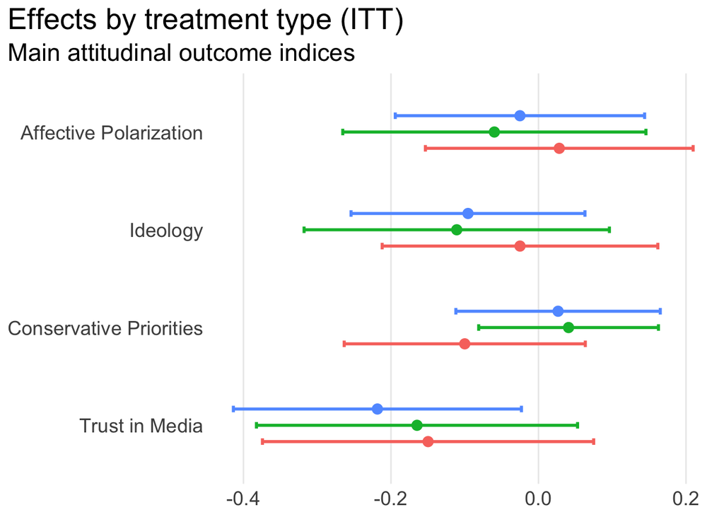

```r
general_models <- list(
    lm(affective_index.post ~ treated + affective_index + ideo + age + gender + educ, data = survey_df),
    lm(ideological_index.post ~ treated + ideological_index + ideo + age + gender + educ, data = survey_df),
    lm(conservative_priorities_index.post ~ treated + conservative_priorities_index + ideo + age + gender + educ, data = survey_df),
    lm(trust_index.post ~ treated + trust_index + ideo + age + gender + educ, data = survey_df)
)

links <- survey_df %>% filter(treatment_group %in% c(0, 1))
link_models <- list(
    lm(affective_index.post ~ treated + affective_index + ideo + age + gender + educ, data = links),
    lm(ideological_index.post ~ treated + ideological_index + ideo + age + gender + educ, data = links),
    lm(conservative_priorities_index.post ~ treated + conservative_priorities_index + ideo + age + gender + educ, data = links),
    lm(trust_index.post ~ treated + trust_index + ideo + age + gender + educ, data = links)
)

accounts <- survey_df %>% filter(treatment_group %in% c(0, 2))
account_models <- list(
    lm(affective_index.post ~ treated + affective_index + ideo + age + gender + educ, data = accounts),
    lm(ideological_index.post ~ treated + ideological_index + ideo + age + gender + educ, data = accounts),
    lm(conservative_priorities_index.post ~ treated + conservative_priorities_index + ideo + age + gender + educ, data = accounts),
    lm(trust_index.post ~ treated + trust_index + ideo + age + gender + educ, data = accounts)
)

covariate_labels <- c(
    "Treatment",
    "Affective Polarization Index",
    "Ideology Index",
    "Conservative Priorities Index",
    "Media Trust Index",
    "Ideology",
    "Age",
    "Gender: Male",
    "Gender: Non-Binary",
    "Education (Years)"
)

covariate_labels_nnb <- c(
    "Treatment",
    "Affective Polarization Index",
    "Ideology Index",
    "Conservative Priorities Index",
    "Media Trust Index",
    "Ideology",
    "Age",
    "Gender: Male",
    "Gender: Non-Binary",
    "Education (Years)"
)
get_effects <- function(models, vars, name) {
    estimate <- models %>% map_dbl(~ .x$coefficients[2])
    se <- lapply(models, get_robust_se) %>% map_dbl(~ .x[2])
    lo <- estimate - 1.96 * se
    hi <- estimate + 1.96 * se
    data.frame(
        estimate = estimate,
        outcomes = vars,
        se = se,
        lo = lo,
        hi = hi,
        name = name
    )
}
vars <- c("Affective Polarization", "Ideology", "Conservative Priorities", "Trust in Media")
effect_df <- get_effects(general_models, vars, "All") %>%
    rbind(get_effects(link_models, vars, "Links")) %>%
    rbind(get_effects(account_models, vars, "Accounts")) %>%
    mutate(
        name = factor(name, levels = c("Accounts", "Links", "All")),
        outcomes = factor(outcomes, levels = vars)
    )

ggplot(effect_df, aes(xmin = lo, xmax = hi, x = estimate, y = fct_rev(outcomes), group = name, color = name)) +
    geom_point(size = 3, position = position_dodge(width = 0.5)) +
    geom_errorbarh(height = 0.2, size = 1, position = position_dodge(width = 0.5)) +
    theme_minimal() +
    theme(
        panel.grid.minor = element_blank(),
        panel.grid.major.y = element_blank(),
        axis.title.x = element_blank(),
        axis.title.y = element_blank(),
        plot.title.position = "plot",
        text = element_text(size = 17),
        legend.position = "none"
    ) +
    labs(
        title = "Effects by treatment type (ITT)",
        subtitle = "Main attitudinal outcome indices",
        color = "Treatment type"
    ) +
    guides(color = guide_legend(reverse = TRUE))
```

```r
ggsave("figures/results_main_itt.png", width = 8, height = 5)

stargazer(
    general_models,
    type = "html",
    title = "Treatment Effects (ITT)",
    style = "default",
    se = lapply(general_models, get_robust_se),
    covariate.labels = covariate_labels,
    header = FALSE,
    object.names = FALSE,
    model.names = FALSE,
    float.env = "sidewaystable",
    dep.var.labels = vars,
    out = paste0("results_main_itt", ".tex")
)
```

**Treatment Effects (ITT)**

|  | *Dependent variable:* |  |  |  |
| --- | --- | --- | --- | --- |
|  | Affective Polarization | Ideology | Conservative Priorities | Trust in Media |
|  | (1) | (2) | (3) | (4) |
| Treatment | -0.025 | -0.096 | 0.027 | -0.218** |
|  | (0.086) | (0.081) | (0.071) | (0.100) |
| Affective Polarization Index | 0.402*** |  |  |  |
|  | (0.074) |  |  |  |
| Ideology Index |  | 0.873*** |  |  |
|  |  | (0.074) |  |  |
| Conservative Priorities Index |  |  | 0.846*** |  |
|  |  |  | (0.041) |  |
| Media Trust Index |  |  |  | 0.811*** |
|  |  |  |  | (0.064) |
| Ideology | 0.004 | -0.020 | 0.047** | -0.0001 |
|  | (0.034) | (0.053) | (0.021) | (0.043) |
| Age | -0.007* | 0.006* | 0.002 | 0.003 |
|  | (0.004) | (0.003) | (0.003) | (0.006) |
| Gender: Male | -0.180* | -0.044 | 0.063 | 0.020 |
|  | (0.093) | (0.094) | (0.092) | (0.111) |
| Gender: Non-Binary | 0.075 | -0.158 | 0.124 | 0.224 |
|  | (0.165) | (0.121) | (0.132) | (0.281) |
| Education (Years) | 0.020 | -0.012 | 0.013 | -0.001 |
|  | (0.016) | (0.017) | (0.014) | (0.021) |
| Constant | -0.236 | 0.071 | -0.416** | -0.112 |
|  | (0.266) | (0.256) | (0.210) | (0.366) |
| Observations | 118 | 130 | 132 | 118 |
| R<sup>2</sup> | 0.359 | 0.662 | 0.739 | 0.636 |
| Adjusted R<sup>2</sup> | 0.318 | 0.643 | 0.724 | 0.613 |
| Residual Std. Error | 0.402 (df = 110) | 0.434 (df = 122) | 0.330 (df = 124) | 0.513 (df = 110) |
| F Statistic | 8.803*** (df = 7; 110) | 34.146*** (df = 7; 122) | 50.075*** (df = 7; 124) | 27.512*** (df = 7; 110) |
| *Note:* | p<0.1; p<0.05; p<0.01 |  |  |  |

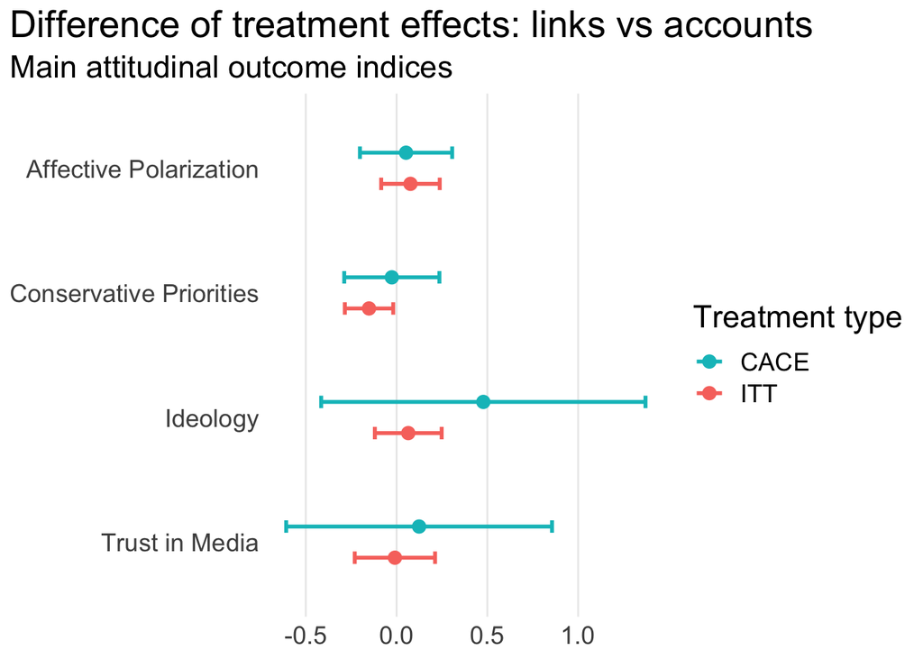

```r
treated_df <- survey_df %>% filter(treatment_group %in% c(1, 2))
general_models <- list(
    lm(affective_index.post ~ social + affective_index + ideo + age + gender + educ, data = treated_df),
    lm(ideological_index.post ~ social + ideological_index + ideo + age + gender + educ, data = treated_df),
    lm(conservative_priorities_index.post ~ social + conservative_priorities_index + ideo + age + gender + educ, data = treated_df),
    lm(trust_index.post ~ social + trust_index + ideo + age + gender + educ, data = treated_df)
)
cace_df <- treated_df %>% filter(total_fox_tweets > 0)
cace_models <- list(
    lm(affective_index.post ~ social + affective_index + ideo + age + gender + educ, data = cace_df),
    lm(ideological_index.post ~ social + ideological_index + ideo + age + gender + educ, data = cace_df),
    lm(conservative_priorities_index.post ~ social + conservative_priorities_index + ideo + age + gender + educ, data = cace_df),
    lm(trust_index.post ~ social + trust_index + ideo + age + gender + educ, data = cace_df)
)
vars <- c("Affective Polarization", "Ideology", "Conservative Priorities", "Trust in Media")
effect_df <- get_effects(general_models, vars, "ITT") %>% rbind(get_effects(cace_models, vars, "CACE"))

ggplot(effect_df, aes(xmin = lo, xmax = hi, x = estimate, y = fct_rev(outcomes), group = name, color = name)) +
    geom_point(size = 3, position = position_dodge(width = 0.5)) +
    geom_errorbarh(height = 0.2, size = 1, position = position_dodge(width = 0.5)) +
    theme_minimal() +
    theme(
        panel.grid.minor = element_blank(),
        panel.grid.major.y = element_blank(),
        axis.title.x = element_blank(),
        axis.title.y = element_blank(),
        plot.title.position = "plot",
        text = element_text(size = 17),
    ) +
    labs(
        title = "Difference of treatment effects: links vs accounts",
        subtitle = "Main attitudinal outcome indices",
        color = "Treatment type"
    ) +
    guides(color = guide_legend(reverse = TRUE))
```

```r
ggsave("figures/results_social.png", width = 8, height = 5)
stargazer(
    general_models,
    type = "html",
    title = "Treatment Effects (Links vs Accounts: ITT)",
    style = "default",
    se = lapply(general_models, get_robust_se),
    covariate.labels = covariate_labels,
    header = FALSE,
    object.names = FALSE,
    model.names = FALSE,
    dep.var.labels = vars,
    float.env = "sidewaystable",
    out = paste0("results_social_itt", ".tex")
)
```

**Treatment Effects (Links vs Accounts: ITT)**

|  | *Dependent variable:* |  |  |  |
| --- | --- | --- | --- | --- |
|  | Affective Polarization | Ideology | Conservative Priorities | Trust in Media |
|  | (1) | (2) | (3) | (4) |
| Treatment | 0.077 | 0.064 | -0.152** | -0.009 |
|  | (0.082) | (0.094) | (0.068) | (0.113) |
| Affective Polarization Index | 0.362*** |  |  |  |
|  | (0.075) |  |  |  |
| Ideology Index |  | 0.922*** |  |  |
|  |  | (0.098) |  |  |
| Conservative Priorities Index |  |  | 0.890*** |  |
|  |  |  | (0.042) |  |
| Media Trust Index |  |  |  | 0.882*** |
|  |  |  |  | (0.072) |
| Ideology | -0.016 | -0.070 | 0.057** | -0.016 |
|  | (0.039) | (0.076) | (0.028) | (0.055) |
| Age | -0.005 | 0.004 | 0.007** | -0.002 |
|  | (0.004) | (0.003) | (0.003) | (0.009) |
| Gender: Male | -0.044 | -0.239** | -0.038 | 0.092 |
|  | (0.102) | (0.120) | (0.137) | (0.117) |
| Gender: Non-Binary | -0.055 | -0.215 | 0.107 | -0.034 |
|  | (0.135) | (0.173) | (0.138) | (0.200) |
| Education (Years) | -0.002 | -0.022 | -0.009 | -0.025 |
|  | (0.018) | (0.023) | (0.017) | (0.026) |
| Constant | -0.026 | 0.257 | -0.120 | 0.206 |
|  | (0.288) | (0.362) | (0.253) | (0.427) |
| Observations | 80 | 85 | 86 | 80 |
| R<sup>2</sup> | 0.350 | 0.665 | 0.789 | 0.691 |
| Adjusted R<sup>2</sup> | 0.286 | 0.634 | 0.770 | 0.661 |
| Residual Std. Error | 0.367 (df = 72) | 0.449 (df = 77) | 0.313 (df = 78) | 0.499 (df = 72) |
| F Statistic | 5.527*** (df = 7; 72) | 21.825*** (df = 7; 77) | 41.691*** (df = 7; 78) | 23.006*** (df = 7; 72) |
| *Note:* | p<0.1; p<0.05; p<0.01 |  |  |  |

```r
stargazer(
    cace_models,
    type = "html",
    title = "Treatment Effects (Links vs Accounts: CACE)",
    style = "default",
    se = lapply(cace_models, get_robust_se),
    covariate.labels = covariate_labels_nnb,
    header = FALSE,
    object.names = FALSE,
    float.env = "sidewaystable",
    model.names = FALSE,
    dep.var.labels = vars,
    out = paste0("results_social_cace", ".tex")
)
```

**Treatment Effects (Links vs Accounts: CACE)**

[output not shown]

### Complier Effects

I don’t think classic CACE estimation is required/appropriate for this experiment.

First, our respondent pool is limited only to those who installed the extension.

We can think of treatment-receivers as those who actually used Twitter and had Fox tweets hidden from them We can think of nontreatment-receivers as those who used Twitter regularly and would have had tweets hidden from them if they had been assigned to treatment eg, they saw some Fox tweets

We can identify these subgroups precisely using the logging data. blacklist_text == true if the content contained a fox link. unfortunately, we have to manually figure out if the account name is in the list of blacklisted authors

We can also identify a different kind of ITT effect on active twitter users broadly, if we want to.

We can also estimate a different kind of CACE effect by the amount of tweets hidden :)

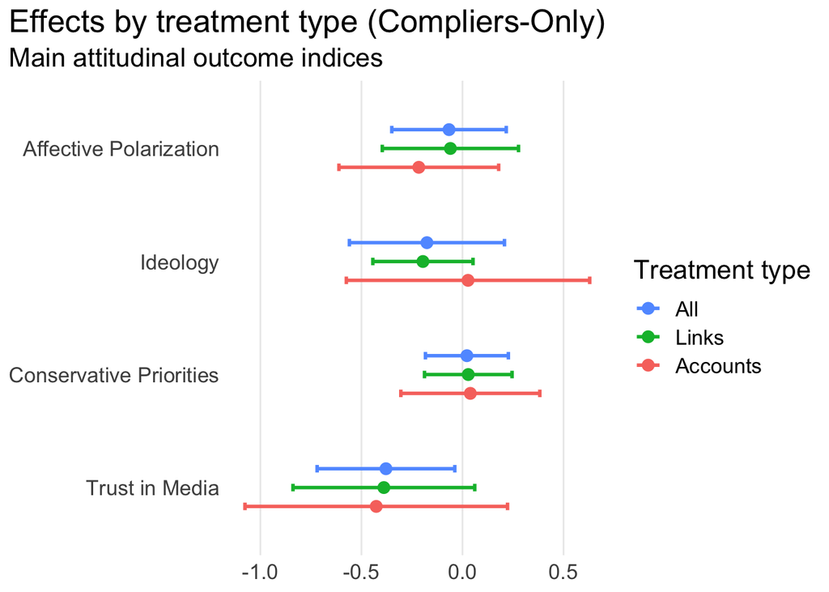

```r
complier_df <- survey_df %>% filter(total_fox_tweets > 0)
general_models <- list(
    lm(affective_index.post ~ treated + affective_index + ideo + age + gender + educ, data = complier_df),
    lm(ideological_index.post ~ treated + ideological_index + ideo + age + gender + educ, data = complier_df),
    lm(conservative_priorities_index.post ~ treated + conservative_priorities_index + ideo + age + gender + educ, data = complier_df),
    lm(trust_index.post ~ treated + trust_index + ideo + age + gender + educ, data = complier_df)
)

links <- complier_df %>% filter(treatment_group %in% c(0, 1))
link_models <- list(
    lm(affective_index.post ~ treated + affective_index + ideo + age + gender + educ, data = links),
    lm(ideological_index.post ~ treated + ideological_index + ideo + age + gender + educ, data = links),
    lm(conservative_priorities_index.post ~ treated + conservative_priorities_index + ideo + age + gender + educ, data = links),
    lm(trust_index.post ~ treated + trust_index + ideo + age + gender + educ, data = links)
)

accounts <- complier_df %>% filter(treatment_group %in% c(0, 2))
account_models <- list(
    lm(affective_index.post ~ treated + affective_index + ideo + age + gender + educ, data = accounts),
    lm(ideological_index.post ~ treated + ideological_index + ideo + age + gender + educ, data = accounts),
    lm(conservative_priorities_index.post ~ treated + conservative_priorities_index + ideo + age + gender + educ, data = accounts),
    lm(trust_index.post ~ treated + trust_index + ideo + age + gender + educ, data = accounts)
)

effect_df <- get_effects(general_models, vars, "All") %>%
    rbind(get_effects(link_models, vars, "Links")) %>%
    rbind(get_effects(account_models, vars, "Accounts")) %>%
    mutate(
        name = factor(name, levels = c("Accounts", "Links", "All")),
        outcomes = factor(outcomes, levels = vars)
    )

ggplot(effect_df, aes(xmin = lo, xmax = hi, x = estimate, y = fct_rev(outcomes), group = name, color = name)) +
    geom_point(size = 3, position = position_dodge(width = 0.5)) +
    geom_errorbarh(height = 0.2, size = 1, position = position_dodge(width = 0.5)) +
    theme_minimal() +
    theme(
        panel.grid.minor = element_blank(),
        panel.grid.major.y = element_blank(),
        axis.title.x = element_blank(),
        axis.title.y = element_blank(),
        plot.title.position = "plot",
        text = element_text(size = 16)
    ) +
    labs(
        title = "Effects by treatment type (Compliers-Only)",
        subtitle = "Main attitudinal outcome indices",
        color = "Treatment type"
    ) +
    guides(color = guide_legend(reverse = TRUE))
```

```r
ggsave("figures/results_main_cace.png", width = 8, height = 5)
stargazer(
    general_models,
    type = "html",
    title = "Treatment Effects (CACE)",
    style = "default",
    se = lapply(general_models, get_robust_se),
    covariate.labels = covariate_labels_nnb,
    float.env = "sidewaystable",
    header = FALSE,
    object.names = FALSE,
    model.names = FALSE,
    dep.var.labels = vars,
    out = paste0("results_main_cace", ".tex")
)
```

[output not shown]

todo: per tweet effects

also, probably more descriptive analysis?

## Are effects stronger for people who use twitter more?

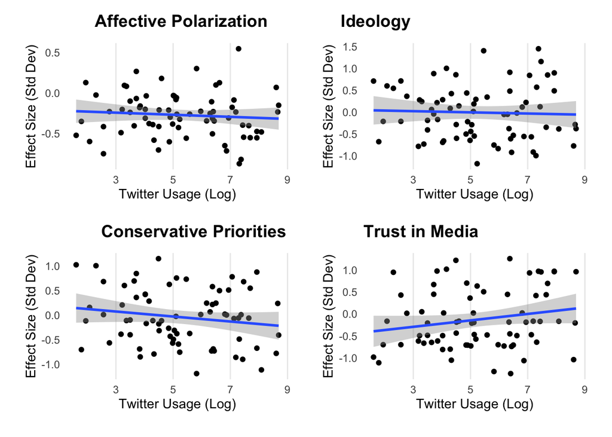

```r
models <- list(
    lm(affective_index.post ~ treated + affective_index + ideo + age + gender + educ, data = survey_df),
    lm(ideological_index.post ~ treated + ideological_index + ideo + age + gender + educ, data = survey_df),
    lm(conservative_priorities_index.post ~ treated + conservative_priorities_index + ideo + age + gender + educ, data = survey_df),
    lm(trust_index.post ~ treated + trust_index + ideo + age + gender + educ, data = survey_df)
)
plts <- lapply(
    models,
    function(x) {
        data.frame(
            coef = predict(x, survey_df),
            tft = log(survey_df$total_tweets + 1)
        ) %>%
            filter(tft != 0) %>%
            ggplot(aes(x = tft, y = coef)) +
            geom_point() +
            geom_smooth(method = "lm") +
            theme_minimal() +
            theme(
                panel.grid.minor = element_blank(),
                panel.grid.major.y = element_blank(),
                plot.title.position = "plot",
                plot.margin = margin(1, 0.5, 0.5, 0.5, "cm")
            ) +
            labs(
                x = "Twitter Usage (Log)",
                y = "Effect Size (Std Dev)",
            )
    }
)
ggarrange(plotlist = plts, labels = vars) + theme(
    plot.margin = margin(0.25, 0.25, 0.25, 0.25, "cm")
)
```

```r
ggsave("figures/interaction_twitter_usage.png", width = 8, height = 8)
```

```r
models <- list(
    lm(affective_index.post ~ treated * twitter_proportion + affective_index + ideo + age + gender + educ, data = survey_df),
    lm(ideological_index.post ~ treated * twitter_proportion + ideological_index + ideo + age + gender + educ, data = survey_df),
    lm(conservative_priorities_index.post ~ treated * twitter_proportion + conservative_priorities_index + ideo + age + gender + educ, data = survey_df),
    lm(trust_index.post ~ treated * twitter_proportion + trust_index + ideo + age + gender + educ, data = survey_df)
)


results <- plot_effects(
    models,
    "treatedTRUE:twitter_proportion",
    "Media Usage Interaction Effects",
    "",
    "results_media_interaction",
    c(
        "Treated",
        "Relative Internet Usage",
        "Affective Polarization Index",
        "Ideology Index",
        "Conservative Priorities Index",
        "Media Trust Index",
        "Ideology",
        "Age",
        "Gender (Male)",
        "Gender (Nonbinary)",
        "Education (Years)",
        "Treated * Relative Internet Usage"
    )
)
```

**Media Usage Interaction Effects**

|  | *Dependent variable:* |  |  |  |
| --- | --- | --- | --- | --- |
|  | Affective Polarization | Ideology | Conservative Priorities | Trust in Media |
|  | (1) | (2) | (3) | (4) |
| Treated | -0.113 | -0.244 | -0.238 | -0.672*** |
|  | (0.217) | (0.249) | (0.171) | (0.205) |
| Relative Internet Usage | 0.001 | -0.066 | -0.405 | -0.594 |
|  | (0.386) | (0.419) | (0.287) | (0.413) |
| Affective Polarization Index | 0.407*** |  |  |  |
|  | (0.075) |  |  |  |
| Ideology Index |  | 0.877*** |  |  |
|  |  | (0.076) |  |  |
| Conservative Priorities Index |  |  | 0.852*** |  |
|  |  |  | (0.043) |  |
| Media Trust Index |  |  |  | 0.803*** |
|  |  |  |  | (0.064) |
| Ideology | 0.005 | -0.016 | 0.054** | 0.015 |
|  | (0.035) | (0.051) | (0.022) | (0.043) |
| Age | -0.007* | 0.006** | 0.002 | 0.003 |
|  | (0.004) | (0.003) | (0.003) | (0.006) |
| Gender (Male) | -0.178* | -0.041 | 0.046 | -0.006 |
|  | (0.095) | (0.091) | (0.094) | (0.117) |
| Gender (Nonbinary) | 0.077 | -0.153 | 0.135 | 0.243 |
|  | (0.168) | (0.124) | (0.141) | (0.288) |
| Education (Years) | 0.021 | -0.010 | 0.014 | 0.001 |
|  | (0.016) | (0.017) | (0.014) | (0.021) |
| Treated * Relative Internet Usage | 0.190 | 0.328 | 0.581 | 1.020** |
|  | (0.432) | (0.507) | (0.359) | (0.491) |
| Constant | -0.263 | 0.065 | -0.245 | 0.087 |
|  | (0.302) | (0.303) | (0.257) | (0.393) |
| Observations | 118 | 130 | 132 | 118 |
| R<sup>2</sup> | 0.363 | 0.665 | 0.744 | 0.647 |
| Adjusted R<sup>2</sup> | 0.310 | 0.640 | 0.725 | 0.618 |
| Residual Std. Error | 0.404 (df = 108) | 0.436 (df = 120) | 0.330 (df = 122) | 0.511 (df = 108) |
| F Statistic | 6.828*** (df = 9; 108) | 26.484*** (df = 9; 120) | 39.451*** (df = 9; 122) | 21.989*** (df = 9; 108) |
| *Note:* | p<0.1; p<0.05; p<0.01 |  |  |  |

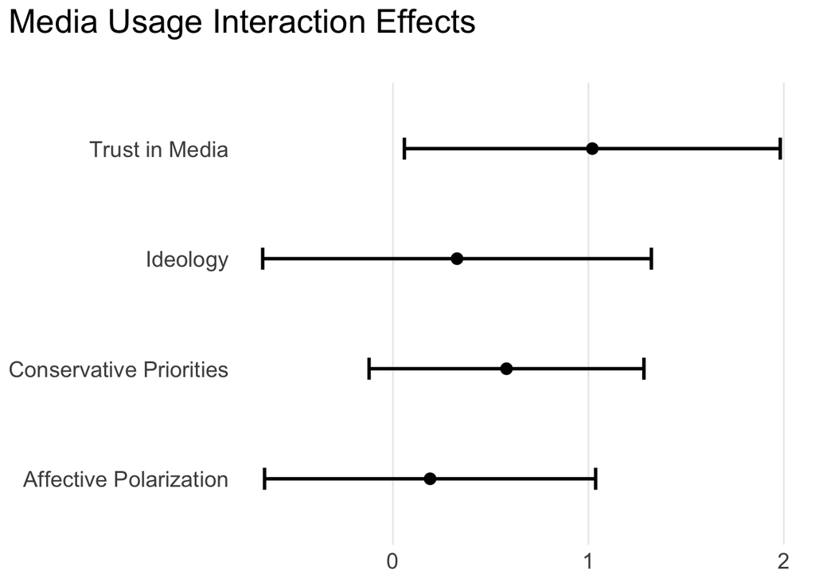

```r
results$plot
```

## Effects by Partisanship

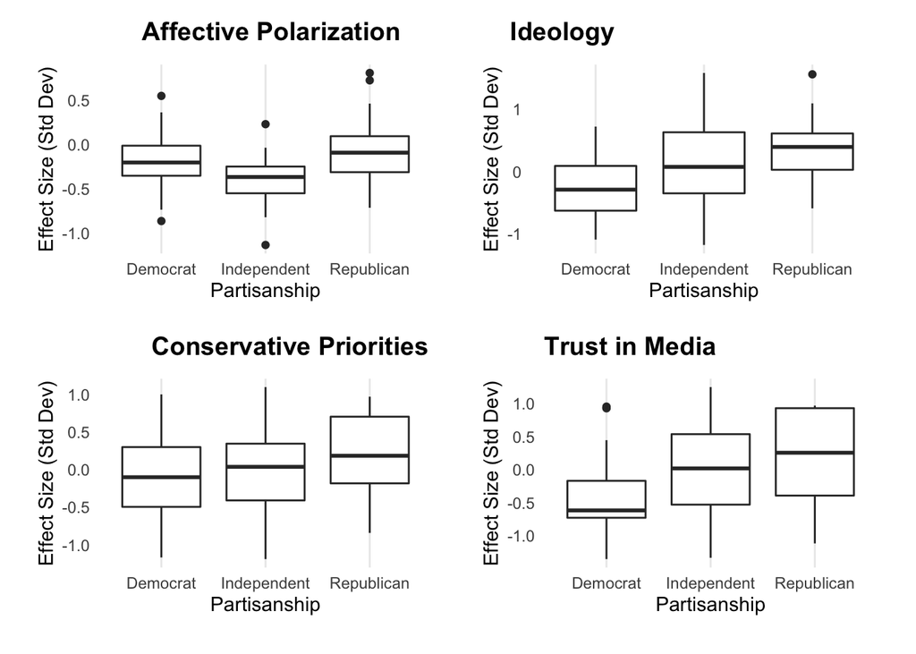

```r
models <- list(
    lm(affective_index.post ~ treated + affective_index + age + gender + educ, data = survey_df),
    lm(ideological_index.post ~ treated + ideological_index + age + gender + educ, data = survey_df),
    lm(conservative_priorities_index.post ~ treated + conservative_priorities_index + age + gender + educ, data = survey_df),
    lm(trust_index.post ~ treated + trust_index + age + gender + educ, data = survey_df)
)

plts <- lapply(
    models,
    function(x) {
        data.frame(
            coef = predict(x, survey_df),
            tft = factor(survey_df$pid3)
        ) %>%
            filter(!is.na(tft)) %>%
            ggplot(aes(x = tft, y = coef)) +
            geom_boxplot() +
            theme_minimal() +
            theme(
                panel.grid.minor = element_blank(),
                panel.grid.major.y = element_blank(),
                plot.title.position = "plot",
                plot.margin = margin(1, 0.5, 0.5, 0.5, "cm"),
            ) +
            labs(
                x = "Partisanship",
                y = "Effect Size (Std Dev)",
            )
    }
)
ggarrange(plotlist = plts, labels = vars) + theme(
    plot.margin = margin(0.25, 0.25, 0.25, 0.25, "cm")
)
```

```r
ggsave("figures/interaction_effects_partisanship_.png", width = 8, height = 8)
models <- list(
    lm(affective_index.post ~ treated * pid3 + affective_index + ideo + age + gender + educ, data = survey_df),
    lm(ideological_index.post ~ treated * pid3 + ideological_index + ideo + age + gender + educ, data = survey_df),
    lm(conservative_priorities_index.post ~ treated * pid3 + conservative_priorities_index + ideo + age + gender + educ, data = survey_df),
    lm(trust_index.post ~ treated * pid3 + trust_index + ideo + age + gender + educ, data = survey_df)
)


results <- plot_effects(
    models,
    "treatedTRUE:pid3",
    "Partisanship Interaction Effects",
    "",
    "results_partisanship_interaction",
    c(
        "Treated",
        "Partisanship: Independent",
        "Partisanship: Republican",
        "Affective Polarization Index",
        "Ideology Index",
        "Conservative Priorities Index",
        "Media Trust Index",
        "Ideology",
        "Age",
        "Gender (Male)",
        "Gender (Nonbinary)",
        "Education (Years)",
        "Treated * Partisanship: Independent",
        "Treated * Partisanship: Republican"
    )
)
```

[output not shown]

[output cut: 20 more lines]

## What kind of content is replaced?

```r
models <- list(
    lm(proportion_liberal ~ treated + ideo + age + gender + educ, data = survey_df),
    lm(proportion_political ~ treated + ideo + ideo + age + gender + educ, data = survey_df),
    lm(log(total_tweets + 1) ~ treated + ideo + age + gender + educ, data = survey_df)
)
cace_models <- list(
    lm(proportion_liberal ~ treated + ideo + age + gender + educ, data = survey_df %>% filter(total_fox_tweets > 0)),
    lm(proportion_political ~ treated + ideo + ideo + age + gender + educ, data = survey_df %>% filter(total_fox_tweets > 0)),
    lm(log(total_tweets + 1) ~ treated + ideo + age + gender + educ, data = survey_df %>% filter(total_fox_tweets > 0))
)
stargazer(
    models,
    type = "html",
    title = "Treatment Effects on Twitter Content",
    style = "default",
    se = lapply(models, get_robust_se),
    covariate.labels = c(
        "Treatment",
        "Ideology",
        "Age",
        "Gender (Male)",
        "Gender (Non-binary)",
        "Education (Years)"
    ),
    header = FALSE,
    object.names = FALSE,
    model.names = FALSE,
    dep.var.labels = c("Proportion Left-leaning Tweets", "Proportion Political", "log Total Tweets"),
    out = paste0("results_twitter", ".tex")
)
```

**Treatment Effects on Twitter Content**

|  | *Dependent variable:* |  |  |
| --- | --- | --- | --- |
|  | Proportion Left-leaning Tweets | Proportion Political | log Total Tweets |
|  | (1) | (2) | (3) |
| Treatment | 0.037 | -0.041 | 0.147 |
|  | (0.061) | (0.031) | (0.551) |
| Ideology | 0.020 | 0.001 | -0.222 |
|  | (0.022) | (0.011) | (0.223) |
| Age | -0.002 | 0.003** | 0.037 |
|  | (0.002) | (0.001) | (0.023) |
| Gender (Male) | 0.146* | 0.044 | -1.166** |
|  | (0.080) | (0.047) | (0.553) |
| Gender (Non-binary) | 0.014 | 0.029 | 1.483 |
|  | (0.055) | (0.086) | (1.279) |
| Education (Years) | 0.006 | 0.010 | -0.017 |
|  | (0.014) | (0.008) | (0.118) |
| Constant | 0.015 | -0.097 | 2.422 |
|  | (0.208) | (0.117) | (1.922) |
| Observations | 66 | 72 | 127 |
| R<sup>2</sup> | 0.101 | 0.143 | 0.070 |
| Adjusted R<sup>2</sup> | 0.010 | 0.064 | 0.024 |
| Residual Std. Error | 0.209 (df = 59) | 0.132 (df = 65) | 2.928 (df = 120) |
| F Statistic | 1.105 (df = 6; 59) | 1.803 (df = 6; 65) | 1.511 (df = 6; 120) |
| *Note:* | p<0.1; p<0.05; p<0.01 |  |  |

## Effects by left leaningness

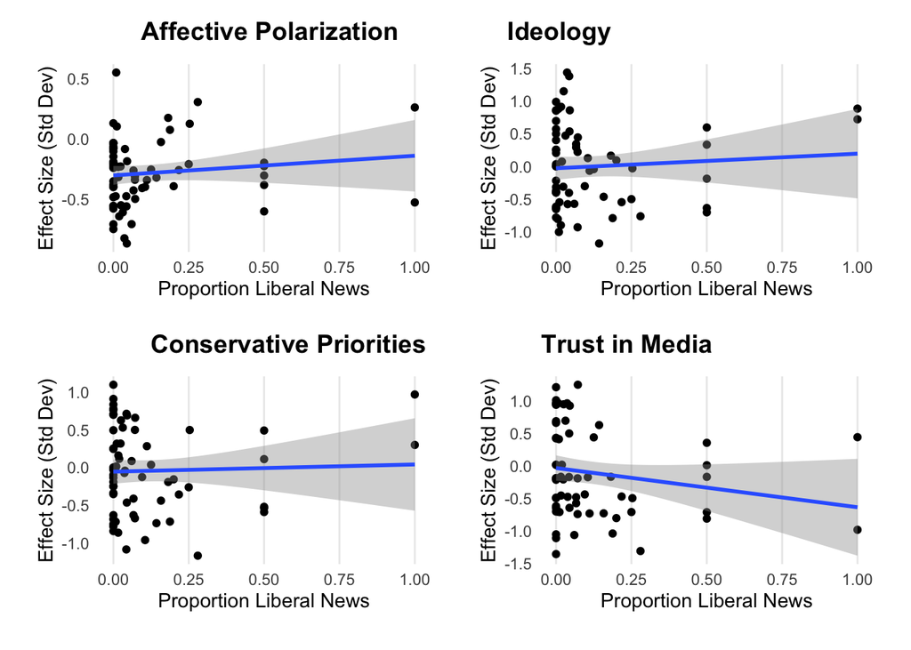

```r
models <- list(
    lm(affective_index.post ~ treated + affective_index + age + gender + educ, data = survey_df),
    lm(ideological_index.post ~ treated + ideological_index + age + gender + educ, data = survey_df),
    lm(conservative_priorities_index.post ~ treated + conservative_priorities_index + age + gender + educ, data = survey_df),
    lm(trust_index.post ~ treated + trust_index + age + gender + educ, data = survey_df)
)
plts <- lapply(
    models,
    function(x) {
        data.frame(
            coef = predict(x, survey_df),
            tft = survey_df$proportion_liberal
        ) %>%
            filter(!is.na(tft)) %>%
            ggplot(aes(x = tft, y = coef)) +
            geom_point() +
            geom_smooth(method = "lm") +
            theme_minimal() +
            theme(
                panel.grid.minor = element_blank(),
                panel.grid.major.y = element_blank(),
                plot.title.position = "plot",
                plot.margin = margin(1, 0.5, 0.5, 0.5, "cm")
            ) +
            labs(
                x = "Proportion Liberal News",
                y = "Effect Size (Std Dev)",
            )
    }
)
ggarrange(plotlist = plts, labels = vars) + theme(
    plot.margin = margin(0.25, 0.25, 0.25, 0.25, "cm")
)
```

```r
ggsave("figures/lib_news_interaction.png", width = 8, height = 8)
```

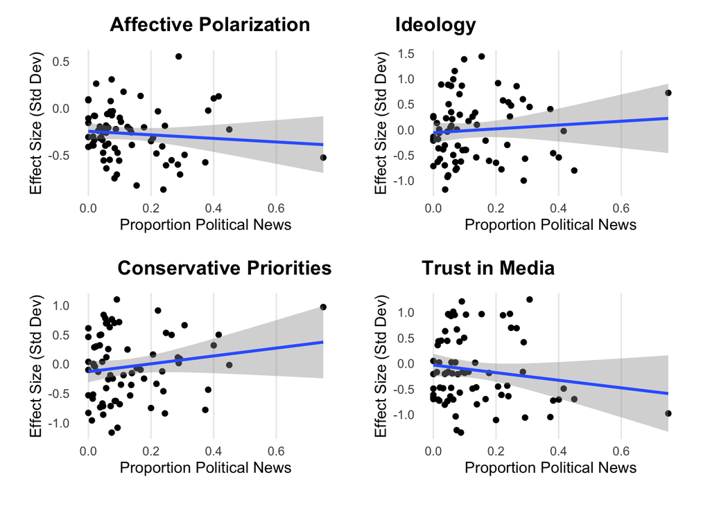

```r
plts <- lapply(
    models,
    function(x) {
        data.frame(
            coef = predict(x, survey_df),
            tft = survey_df$proportion_political
        ) %>%
            filter(!is.na(tft)) %>%
            ggplot(aes(x = tft, y = coef)) +
            geom_point() +
            geom_smooth(method = "lm") +
            theme_minimal() +
            theme(
                panel.grid.minor = element_blank(),
                panel.grid.major.y = element_blank(),
                plot.title.position = "plot",
                plot.margin = margin(1, 0.5, 0.5, 0.5, "cm")
            ) +
            labs(
                x = "Proportion Political News",
                y = "Effect Size (Std Dev)",
            )
    }
)
ggarrange(plotlist = plts, labels = vars) + theme(
    plot.margin = margin(0.25, 0.25, 0.25, 0.25, "cm")
)
```

```r
ggsave("figures/political_news_interaction.png", width = 8, height = 8)
```

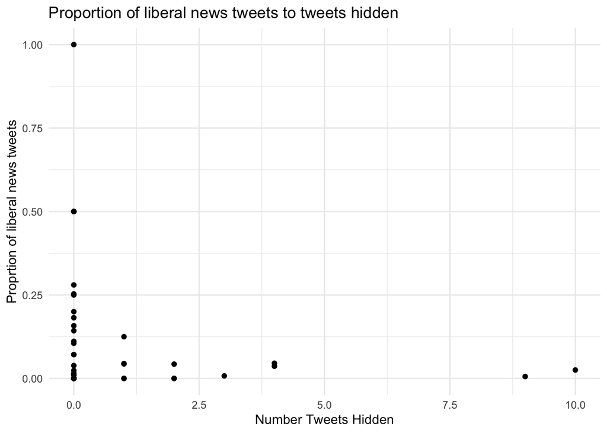

```r
survey_df %>%
    filter(treated & total_tweets > 0) %>%
    ggplot(aes(x = total_hidden, y = proportion_liberal)) +
    geom_point() +
    theme_minimal() +
    labs(title = "Proportion of liberal news tweets to tweets hidden", x = "Number Tweets Hidden", y = "Proprtion of liberal news tweets")
```

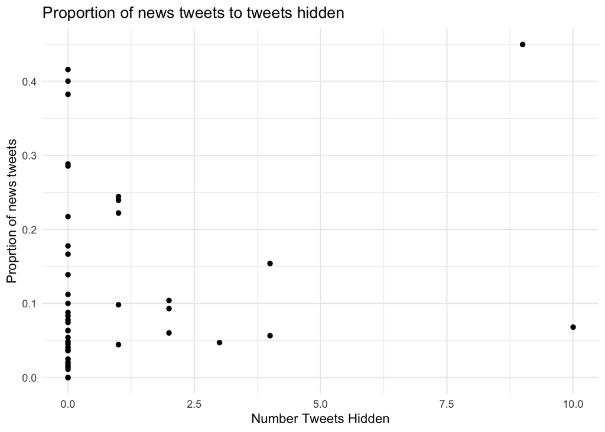

```r
survey_df %>%
    filter(treated & total_tweets > 0) %>%
    ggplot(aes(x = total_hidden, y = proportion_political)) +
    geom_point() +
    theme_minimal() +
    labs(title = "Proportion of news tweets to tweets hidden", x = "Number Tweets Hidden", y = "Proprtion of news tweets")
```

## Per tweet effects

todo this needs reworking

I wonder if IV is the solution for all of these problems? The treatment assignment is an “instrument” for variation in “treatment effect”

Or in other words, the treatment strength is determined by individual level covariates (eg, pre-existing Fox interest) but whether you get treatment or not is randomly assigned

why do we care about this though? i guess we are interested in describing how or if the treatment is more effective for different subpopulations eg, the subpopulation that cares a lot about Fox News but the subpopulation is continuuos andd defined in terms of the treatment strength

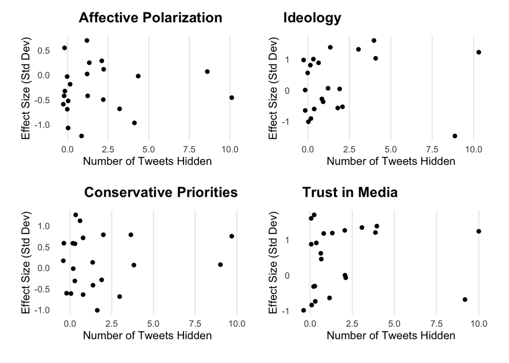

```r
models <- list(
    lm(affective_index.post ~ treated + affective_index + ideo + age + gender + educ, data = complier_df),
    lm(ideological_index.post ~ treated + ideological_index + ideo + age + gender + educ, data = complier_df),
    lm(conservative_priorities_index.post ~ treated + conservative_priorities_index + ideo + age + gender + educ, data = complier_df),
    lm(trust_index.post ~ treated + trust_index + ideo + age + gender + educ, data = complier_df)
)
plts <- lapply(
    models,
    function(x) {
        data.frame(
            coef = predict(x, complier_df),
            tft = complier_df$total_hidden
        ) %>%
            ggplot(aes(x = tft, y = coef)) +
            geom_point(position = position_jitter()) +
            theme_minimal() +
            theme(
                panel.grid.minor = element_blank(),
                panel.grid.major.y = element_blank(),
                plot.title.position = "plot",
                plot.margin = margin(1, 0.5, 0.5, 0.5, "cm")
            ) +
            labs(
                x = "Number of Tweets Hidden",
                y = "Effect Size (Std Dev)",
            )
    }
)
ggarrange(plotlist = plts, labels = vars) + theme(
    plot.margin = margin(0.25, 0.25, 0.25, 0.25, "cm")
)
```

```r
knitr::knit_exit()
```